# Project 2: Data Mining, Classification, Prediction

SDS322E

# Mining, Classification, Prediction

## Haley Harnitchek hmh2475

### Introduction

*I chose this data set because it contains data from the Veteran’s Administration Lung Cancer Trial (Kalbfleisch and Prentice). I thought it was interesting because it shows if treatment helped patients. The data are described here. Treatment denotes the type of lung cancer treatment; 1 (standard) and 2 (test drug). Cell Type denotes the type of cell involved; 1 (squamous), 2 (small cell), 3 (adeno), 4 (large). Survival is the survival time in days since the treatment. Status denotes the status of the patient as dead or alive; 1 (dead), 0 (alive). Karnofsky is the Karnofsky score. Diag is the time since diagnosis in months. Age is the age in years. Therapy denotes any prior therapy; 0 (none), 10 (yes). There are 8 variables and 137 observations for each. There are 1096 observations in total.*

```r
library(dplyr)
library(ggplot2)
VA <- MASS::VA
```

### Cluster Analysis

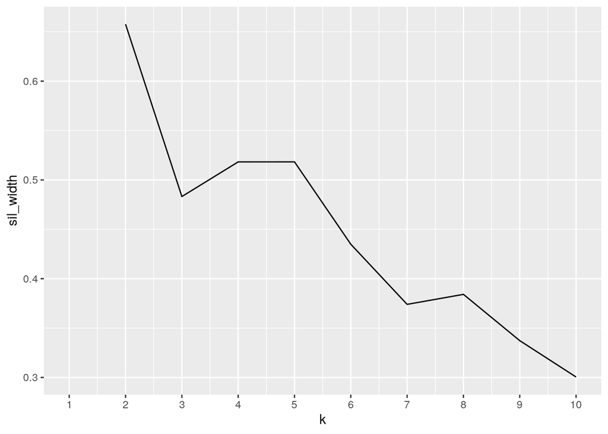

```r
library(cluster)
pam_dat <- VA %>% select(stime, age, Karn, diag.time)
sil_width <- vector()
for (i in 2:10) {
    pam_fit <- pam(pam_dat, k = i)
    sil_width[i] <- pam_fit$silinfo$avg.width
}
ggplot() + geom_line(aes(x = 1:10, y = sil_width)) + scale_x_continuous(name = "k",
    breaks = 1:10)
```

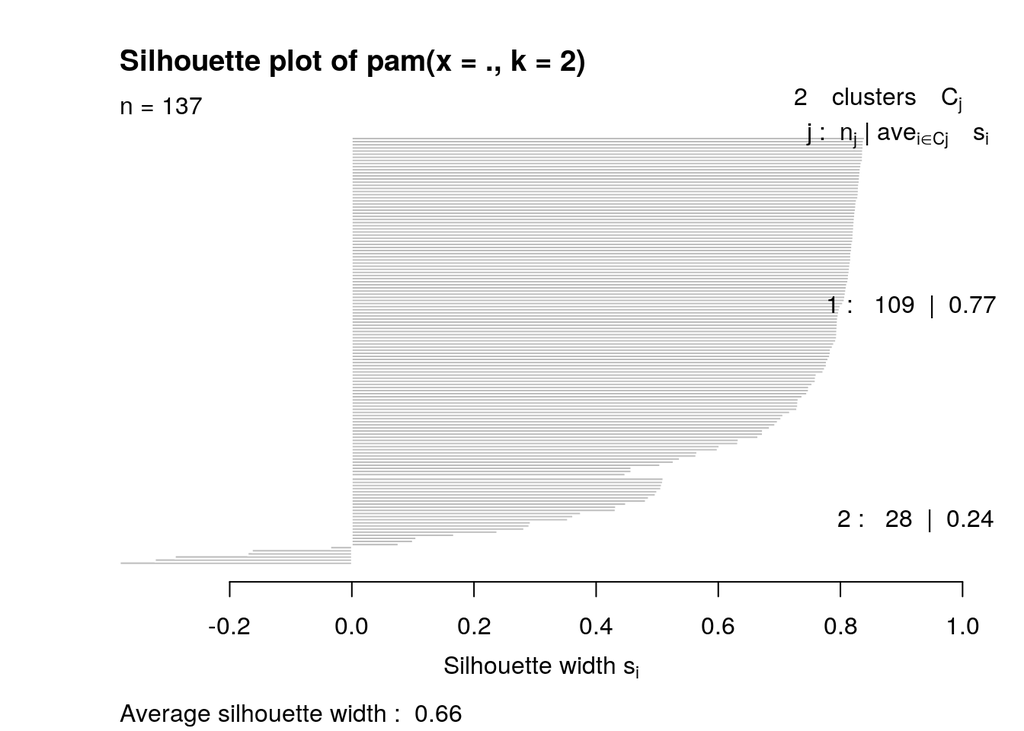

```r
VA_pam <- VA %>% pam(k = 2)
plot(VA_pam, which = 2)
```

```r
VA %>% slice(VA_pam$id.med)
```

```
##   stime status treat age Karn diag.time cell prior
## 1    51      1     2  62   60         5    3     0
## 2   278      1     1  63   60        12    4     0
```

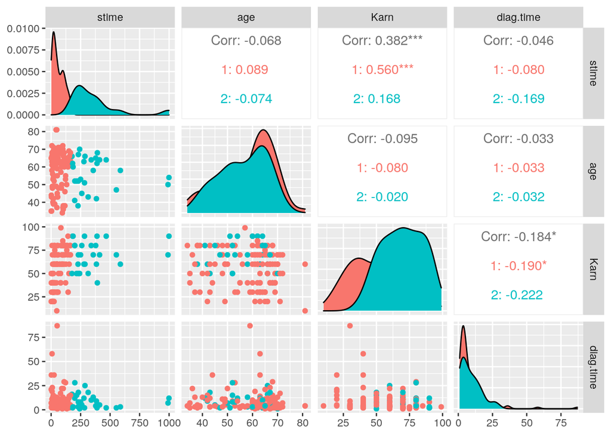

```r
library(GGally)
VA %>% mutate(cluster = as.factor(VA_pam$clustering)) %>% ggpairs(columns = c("stime",
    "age", "Karn", "diag.time"), aes(color = cluster))
```

*I used PAM clustering. Based on the four numeric variables, a 2 cluster solution might be best because the largest average silhoutte width was 0.7 at 2 clusters. A reasonable structure was found because the average silhouette width was 0.7. Using these clusters, I visualized all of the pairwise combinations of the four numeric variables (stime, age, Karn, diag.time). The pairwaise combinations showed that there waws little to no correlation between the four numeric variables. There does seem to be a small positive correlation between stime (survival or follow-up time in days) and Karn (patient performance on a scale of 0 to 100).*